# BANA 7050 - Assignment Final

#### Time series decomposition and Seasonality

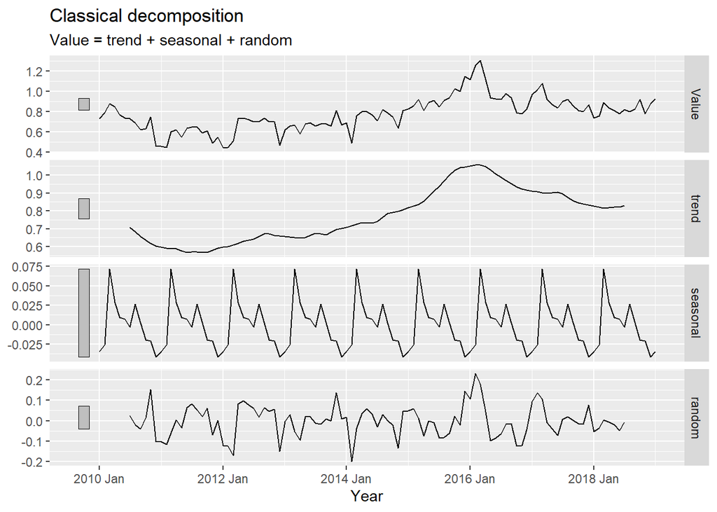

```r
data_train <- as_tsibble(data_train,index = Year, regular = TRUE)

data_train$Year <- as.yearmon(data_train$Year)

data_train$Year <- yearmonth(data_train$Year)

data_train <- as_tsibble(data_train,index = Year)

classicdecom <- data_train %>%
  model(
    classical_decomposition(Value,'additive')
  ) %>%
  components()

autoplot(classicdecom)
```

#### Stationarity Check:

Global temperature anomalies data is prone to a lot of fluctuations due to a multitude of factors. Pollution levels, green house gases, the pandemic in between could have had a significant impact on our data thereby there being a need to check for stationarity/non stationarity.To confirm non stationarity, plotting rolling averages and rolling standard deviations will be our first step in analysis.

*Rolling Average :*

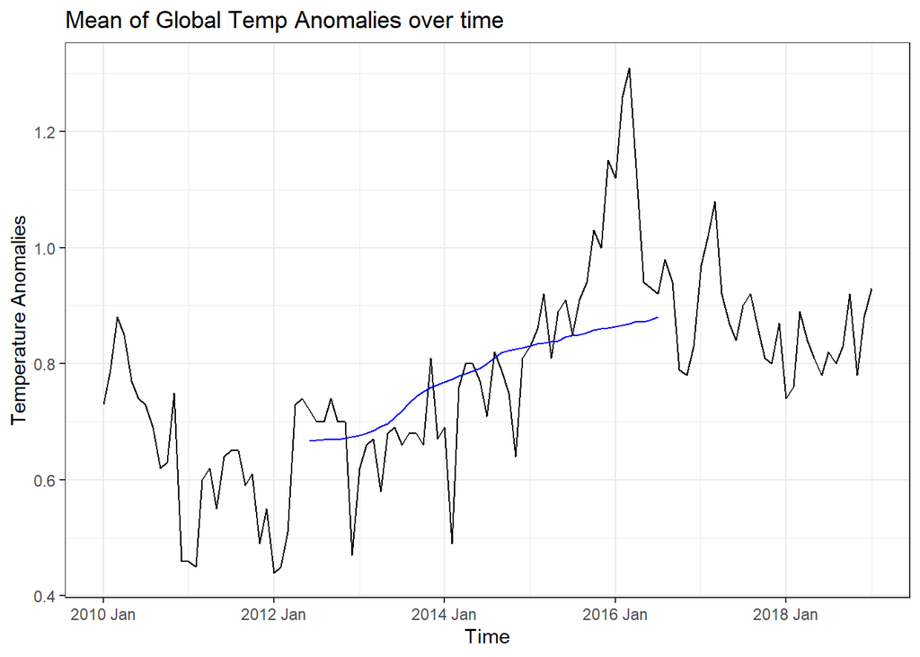

```r
library(zoo)
data_roll <- data_train %>%
  mutate(
    close_mean = zoo::rollmean(
      Value,
      k = 60,
      fill = NA),
    close_sd = zoo::rollapply(
      Value,
      FUN = sd,
      width = 60,
      fill = NA)
  )

data_rollmean <- data_roll %>%
  ggplot() +
    geom_line(aes(Year, Value)) +
  geom_line(aes(Year, close_mean),color='blue') +
  theme_bw() +
  ggtitle("Mean of Global Temp Anomalies over time") +
  ylab("Temperature Anomalies") +
  xlab("Time")

data_rollmean
```

The above plot tells us that the mean is not stationary because it is not constant , confirming our assumptions.

*Rolling Standard Deviation :*

From the below plot, it is obvious that our data is variance non stationary.

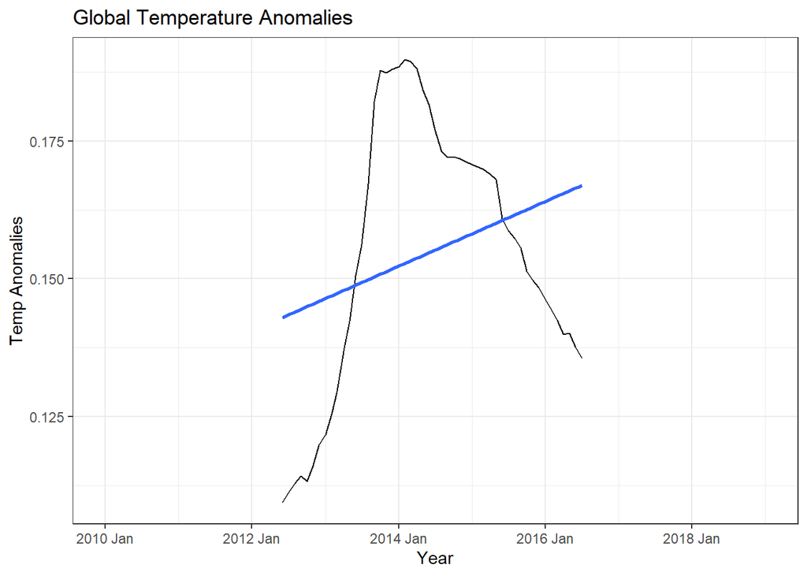

```r
data_rollsd <- data_roll %>%
  ggplot() +
  geom_line(aes(Year, close_sd)) +
  geom_smooth(aes(Year,close_sd),method='lm',se=F)+
  theme_bw() +
  ggtitle("Global Temperature Anomalies") +
  ylab("Temp Anomalies") +
  xlab("Year")

data_rollsd
```

#### Transformation:

**Variance Stationary:**

The data at hand is variance non stationary as seen above, therefore it needs to be transformed.

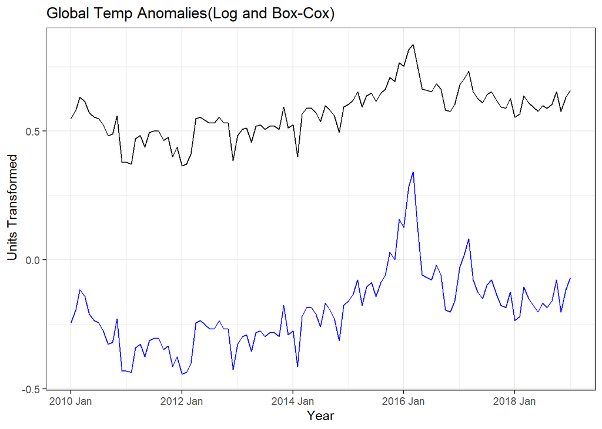

```r
data_trans <- data_train%>%
  mutate(data_log = log1p(Value)) %>%
  mutate(data_boxcox = forecast::BoxCox(Value, lambda = "auto"))

data_trans %>%
  ggplot() +
  geom_line(aes(Year, data_log)) +
  geom_line(aes(Year, data_boxcox),color='blue') +
  theme_bw() +
  ggtitle("Global Temp Anomalies(Log and Box-Cox)") +
  ylab(" Units Transformed") +
  xlab("Year")
```

From the above observations, both box-cox and log transformations are doing good job at making the data variance stationary.

Log transformation reduces variance greatly compared to Box-Cox transformation. So log transformation is preferred over Box-Cox in our case.

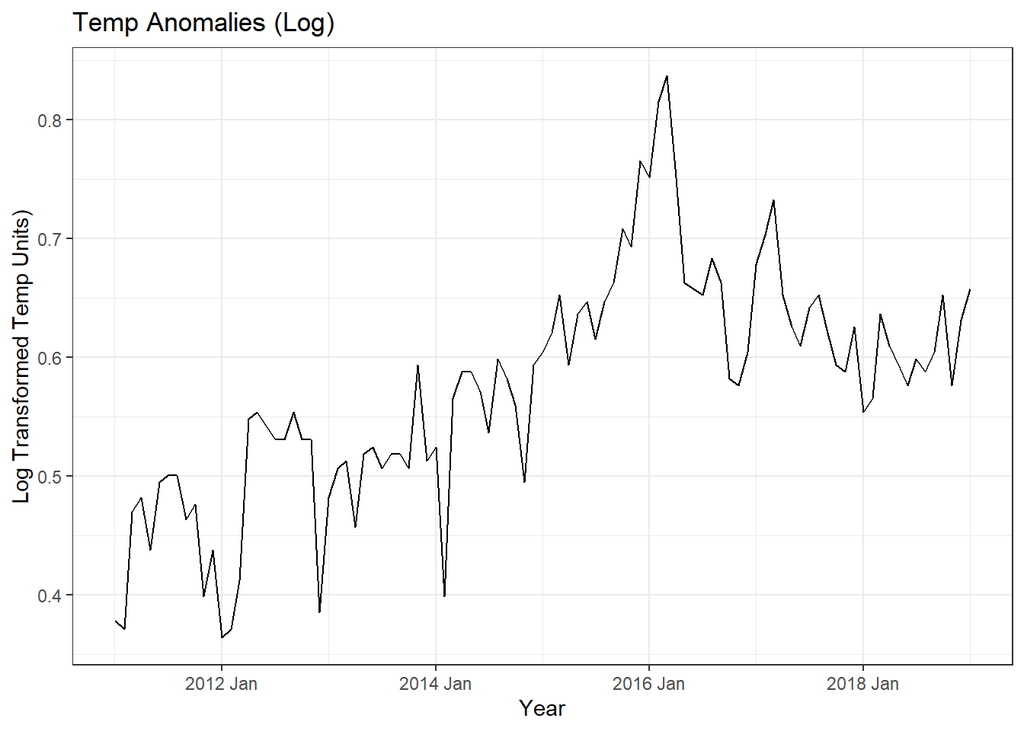

```r
data_diff <- data_train %>%
  mutate(
    data_log = log1p(Value),
    data_log_diff = data_log - lag(data_log,12)) %>%
  drop_na() %>%
  as_tsibble(index=Year)




data_diff %>%
  ggplot() +
  geom_line(aes(Year, data_log)) +
  theme_bw() +
  ggtitle("Temp Anomalies (Log)") +
  ylab("Log Transformed Temp Units)") +
  xlab("Year")+
theme_bw()
```

#### *Seasonally Differenced:*

We know that our temperature anomalies dataset has seasonality in it from prior analysis, we are therefore seasonally differencing it.

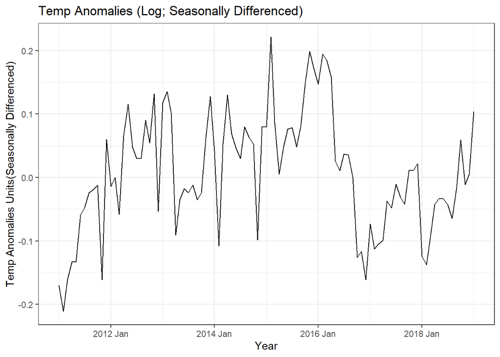

```r
data_diff %>%
  ggplot() +
  geom_line(aes(Year, data_log_diff)) +
  theme_bw() +
  ggtitle("Temp Anomalies (Log; Seasonally Differenced)") +
  ylab("Temp Anomalies Units(Seasonally Differenced)") +
  xlab("Year")+
theme_bw()
```

#### Stationarity Tests:

Performing Augmented Dickey Fuller and KPSS test on the transformed data to check for further presence of non stationarity.

```r
adf.test(data_diff$data_log_diff)
```

```
    Augmented Dickey-Fuller Test

data:  data_diff$data_log_diff
Dickey-Fuller = -2.8501, Lag order = 4, p-value = 0.225
alternative hypothesis: stationary
```

```r
log_diff_kpss = data_diff %>%
features(data_diff, unitroot_kpss)

log_diff_kpss
```

```
# A tibble: 1 × 2
  kpss_stat kpss_pvalue
      <dbl>       <dbl>
1      2.52        0.01
```

The p value after performing **KPSS test is 0.01 which is less than 0.05**, indicating that the transformed data still is non stationary. So, checking if the data is mean non-stationary

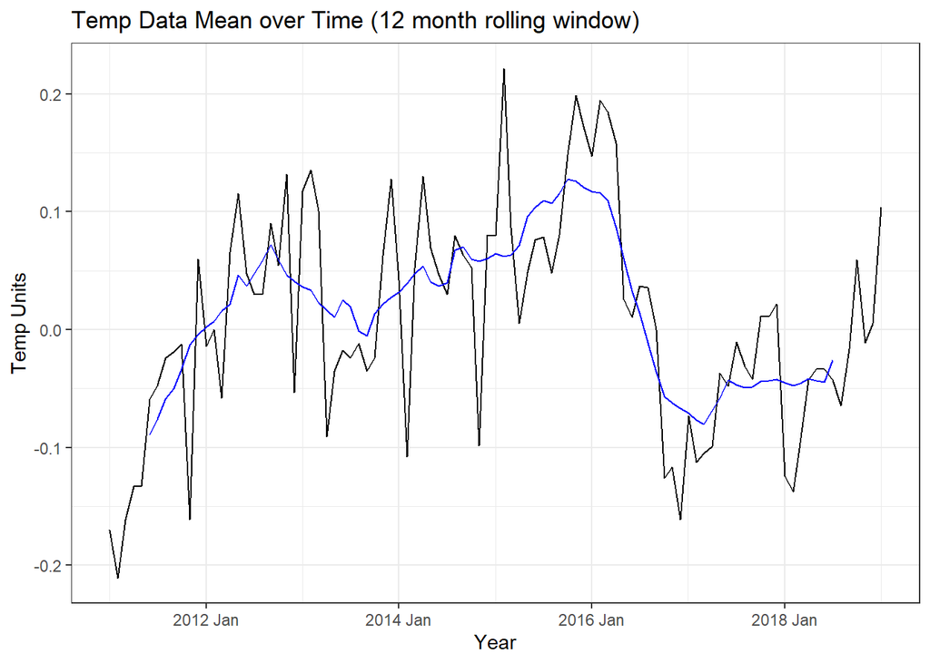

```r
data_roll_trans <- data_diff %>%
  mutate(
    data_mean = zoo::rollmean(
      data_log_diff,
      k = 12,
      fill = NA)
  )

data_roll_trans %>%
  ggplot() +
    geom_line(aes(Year, data_log_diff)) +
  geom_line(aes(Year, data_mean),color='blue') +
  theme_bw() +
  ggtitle("Temp Data Mean over Time (12 month rolling window)") +
  ylab("Temp Units") +
  xlab("Year")
```

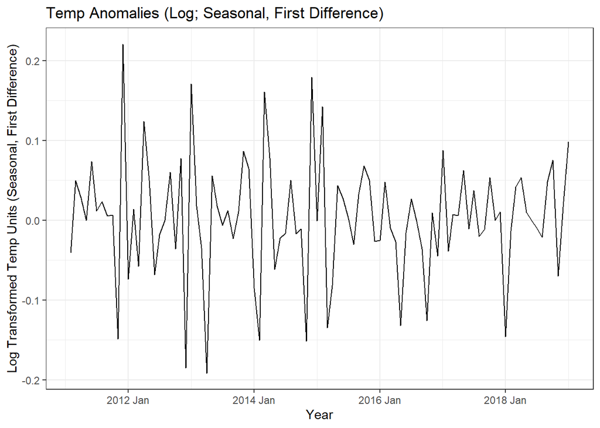

```r
data_diff <- data_diff %>%
  mutate(
    data_log_diff_up = data_log_diff - lag(data_log_diff)) %>%
  drop_na() %>%
  as_tsibble(index=Year)

data_diff %>%
  ggplot() +
  geom_line(aes(Year, data_log_diff_up)) +
  theme_bw() +
  ggtitle("Temp Anomalies (Log; Seasonal, First Difference)") +
  ylab("Log Transformed Temp Units (Seasonal, First Difference)") +
  xlab("Year")+
theme_bw()
```

Performing the KPSS test on the further transformed data to check for remaining non stationarity.

```r
log_diff_kpss_up = data_diff %>%
features(data_log_diff_up, unitroot_kpss)

log_diff_kpss_up
```

```
# A tibble: 1 × 2
  kpss_stat kpss_pvalue
      <dbl>       <dbl>
1    0.0869         0.1
```

*Here the p value is **0.1 which is greater than 0.05**, hence the transformed data is stationary.*

**ACF AND PACF**

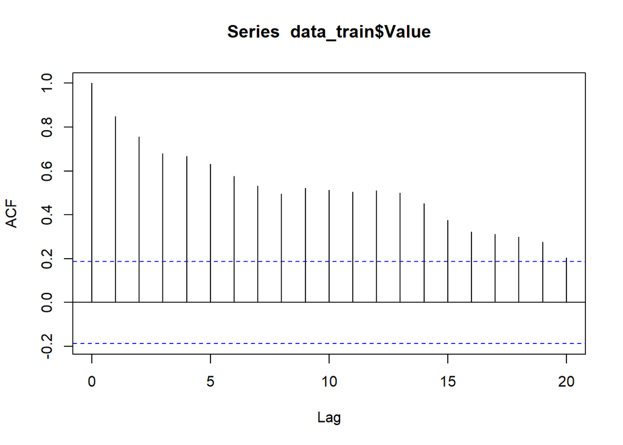

```r
ACF1=acf(data_train$Value) %>%
  autoplot()
```

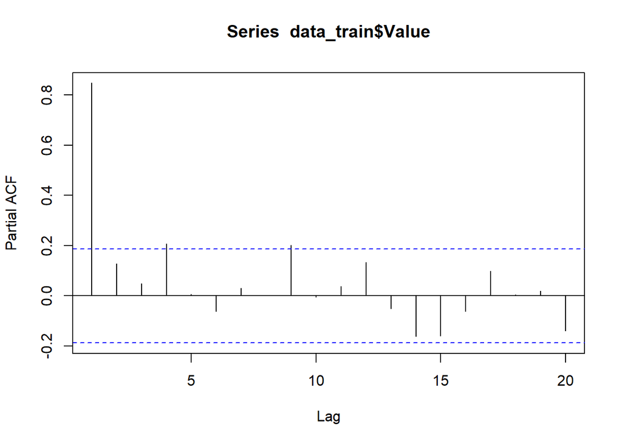

```r
PACF1=pacf(data_train$Value) %>%
  autoplot()
```

*On transformed series:*

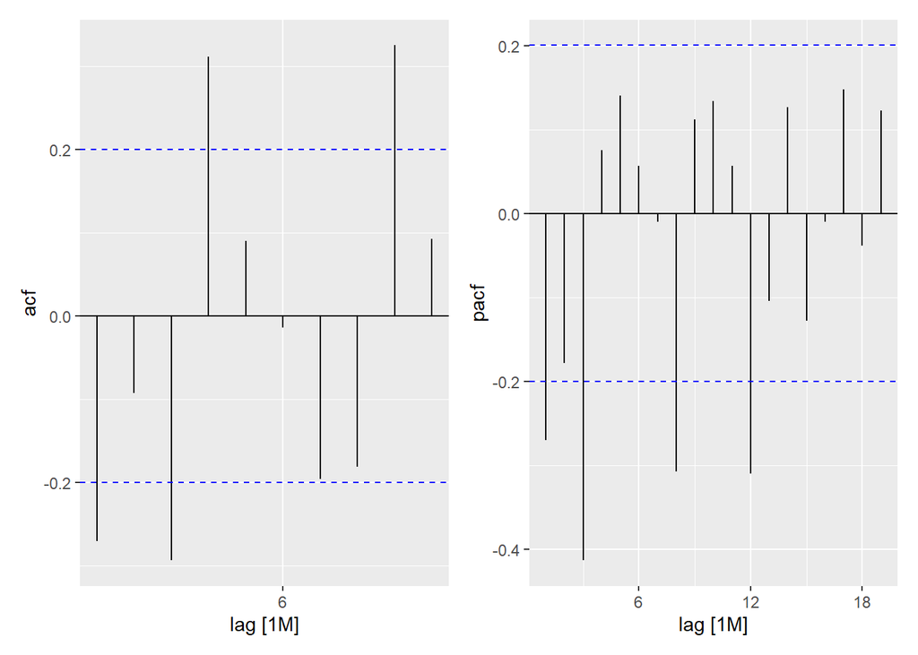

```r
acf = data_diff %>%
  ACF(data_log_diff_up,lag_max=10, na.action = na.pass) %>%
  autoplot()

pacf =  data_diff %>%
  fill_gaps() %>%
  PACF(data_log_diff_up) %>%
  autoplot()

acf + pacf
```